# LCAS Report

LCAS team

2023-09-04

This document provides a sample report for automated insights into drivers and outcomes of crop prodution systems at landscape level as part of the LCAS system.

## Initial overview

First, we need to load the datast of interest. Make sure it has been cleaned properly using the cleaning files.

We can then produce some key statistics to provide and overview of the dataset. The dataset contains data from the following countries: **India,** from the years **2017, 2018** for **Rice**. The average landholding size was **1.15** ha and the average size of the largest plot was **0.238** ha. Data has been collected in the following states/provinces: **Bihar, UttarPradesh**. The dataset contains **9,694** samples. And the following distribution of samples across the sample provinces/states:

| State/Province | % of samples |
| --- | --- |
| Bihar | 73.66 |
| UttarPradesh | 26.34 |

Showing the sample locations

[interactive chart not shown]

## Yield and crop variety patterns

The average yield across the dataset is **4.04 t ha<sup>-1</sup>** with a standard deviation of **1.12 t ha<sup>-1</sup>**.

The mean yield and standard deviation per state/province in descending order:

| State/Province | Mean yield | Standard Deviation |
| --- | --- | --- |
| UttarPradesh | 4.24 | 1.05 |
| Bihar | 3.97 | 1.14 |

The same table per variety looks as follows:

| Variety Type | Mean yield | Standard Deviation |
| --- | --- | --- |
| Improved | 4.09 | 1.15 |
| Hybrid | 3.95 | 1.03 |
| Basmati | 3.30 | 1.11 |
| Local | 3.26 | 1.26 |

The most common varieites grown are the following:

| Variety name | % of samples |
| --- | --- |
| MTU_7029 | 0.25 |
| Arize6444Gold | 0.19 |
| BPT5204 | 0.08 |
| Sarju52 | 0.06 |
| Moti | 0.05 |

The yield distribution looks as follows:

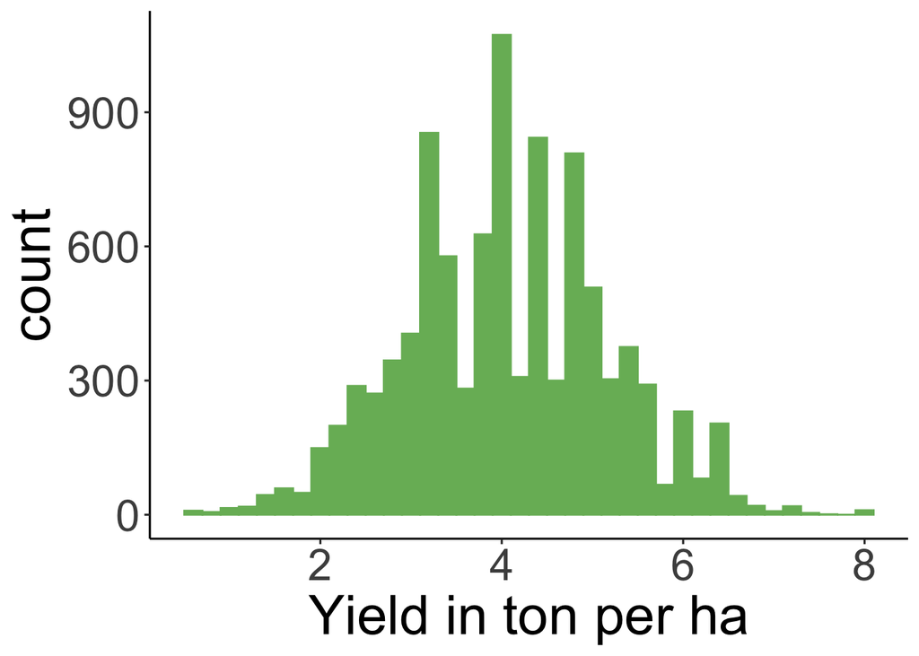

[interactive chart not shown]

## Management practices

On average, rice crops have been (trans)planted or directly sown on **12. of July** and harvested on **14. of November** with **3.95** irrigation events and a total of **127.34** kg urea and **48.46** kg npk applied per plot.

## Irrigation

For the number of irrigation, the basic statistics look as follows:

Mean: **3.95**

Median: **3**

CV: **0.6**

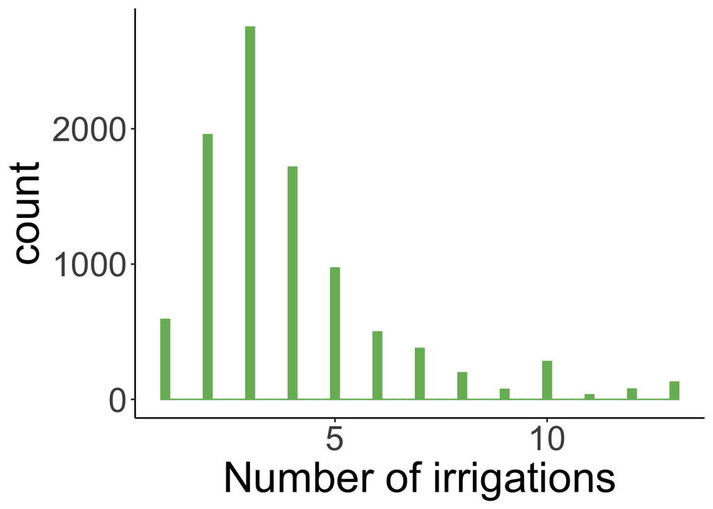

[interactive chart not shown]

## N Rate

For the N rate, the basic statistics look as follows:

Mean: **127.34**

Median: **129.31**

CV: **0.28**

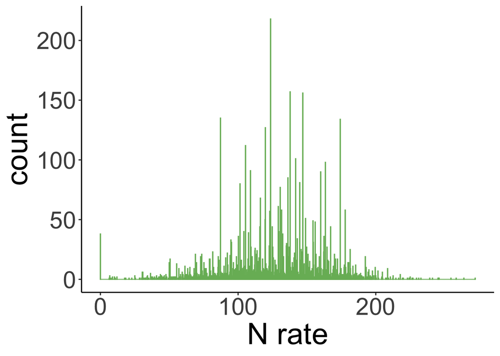

[interactive chart not shown]

## P rate

For the P rate, the basic statistics look as follows:

Mean: **48.46**

Median: **50.1**

CV: **0.48**

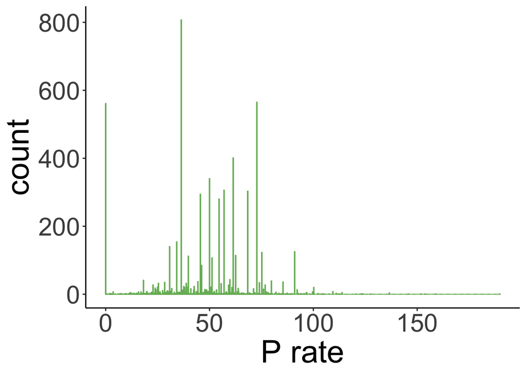

[interactive chart not shown]

## Farm gate price

For the Farm gate price, the basic statistics look as follows:

Unit: **INR / 100 kg**

Mean: **1273.93**

Median: **1250**

CV: **0.17**

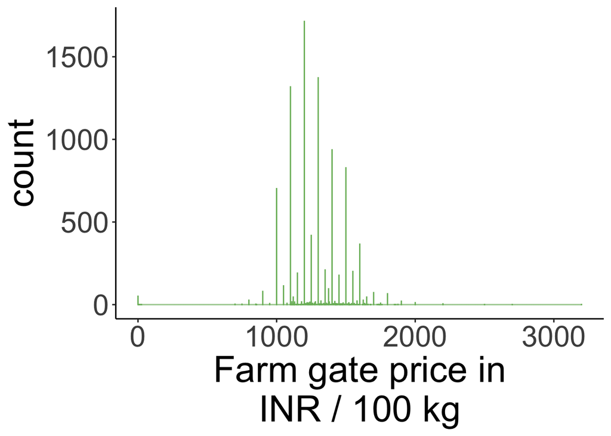

[interactive chart not shown]

## Establishment date

For the Establishment date, the basic statistics look as follows:

Mean: **193.07**

Median: **193**

CV: **0.07**

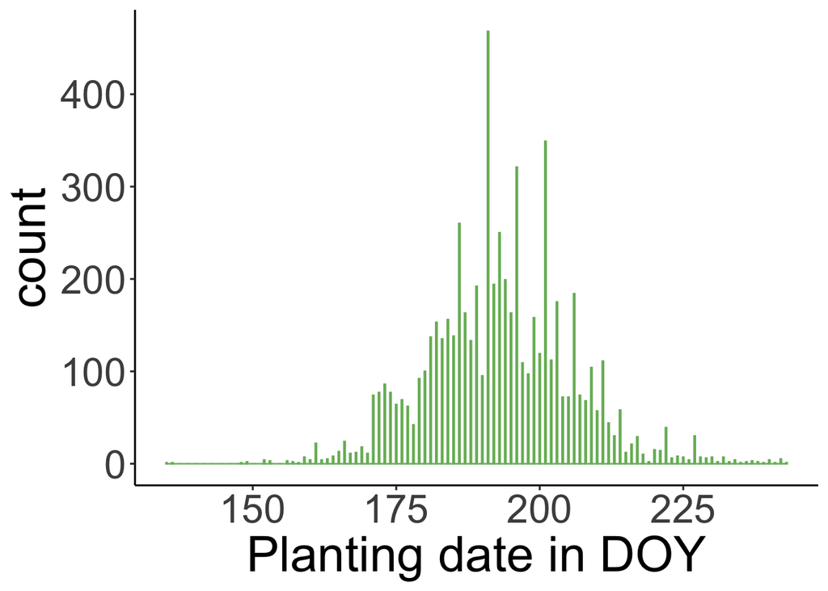

[interactive chart not shown]

## Agriculture income share

For the agriculture income share, the basic statistics look as follows:

Mean: **37.46**

Median: **40**

CV: **0.66**

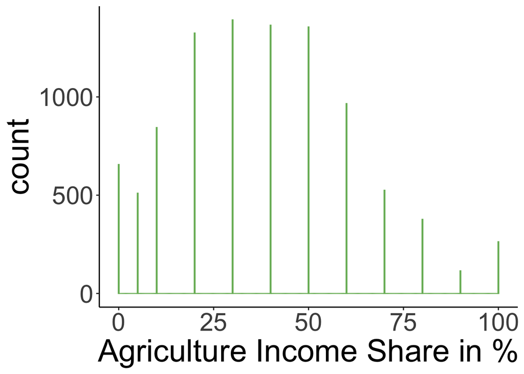

[interactive chart not shown]

## Market sales share

For the Market sales share, the basic statistics look as follows:

Mean: **32.35**

Median: **30**

CV: **0.84**

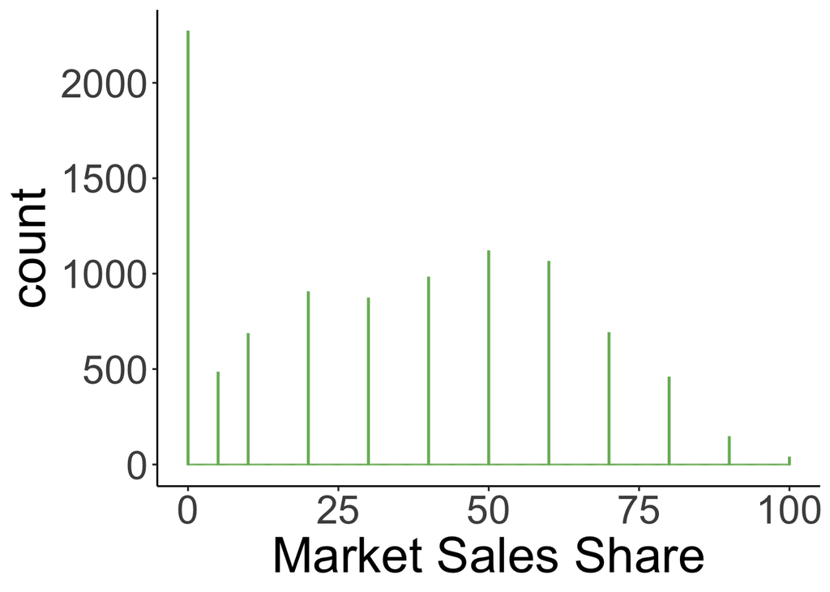

[interactive chart not shown]

# Yield drivers

Constructing random forest yield prediction model and showing the key predictors as well as CART. Note that this is not a robust model, but an automatically generated first brush overview to get a glimpse of variables that are strongly associated with yield outcomes. Random forest models are generally robust in identifying some important variables, but tend to overlook others.

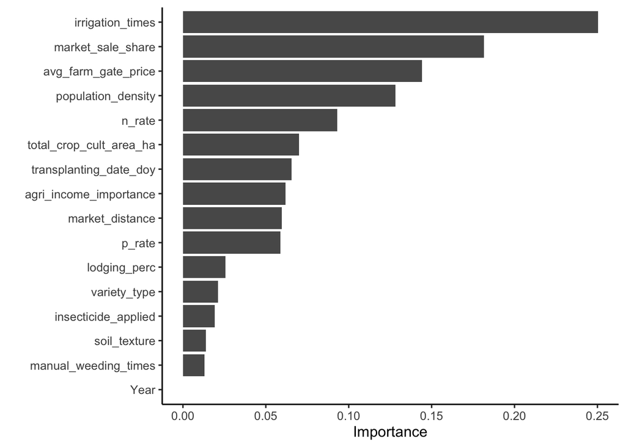

```r
library(ranger)
df1 <- df[,names(df) %in% c("yield_lp_t_ha",
                            "irrigation_times",
                            "n_rate",
                            "p_rate" ,
                            "soil_texture",
                            "transplanting_date_doy" ,
                            "variety_type" ,
                            "population_density" ,
                            "agri_income_importance" ,
                            "Year" ,
                            "market_distance",
                            "market_sale_share",
                            "total_crop_cult_area_ha",
                            "insecticide_applied",
                            "avg_farm_gate_price",
                            "manual_weeding_times",
                            "lodging_perc"
                            )]
df1 <- na.omit(df1)
fit <- ranger(data = df1,  yield_lp_t_ha ~ .,importance = "permutation")
library(vip)
library(randomForestExplainer)
vip::vip(fit,n=20)+
  theme_classic2()
```

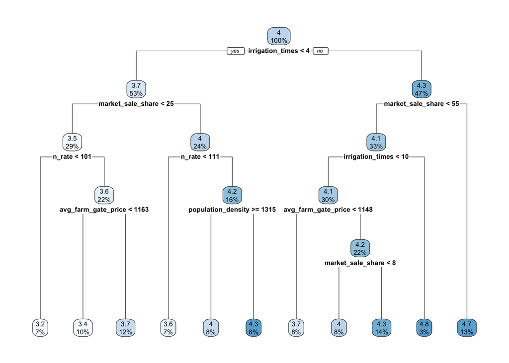

```r
library(rpart)
library(rpart.plot)
#df1$yield_class <- ifelse(df1$yield_lp_t_ha <3.5, "low",
#                          ifelse(df1$yield_lp_t_ha>3.5 & df1$yield_lp_t_ha<5,"medium","high" ))
fit.tree = rpart(yield_lp_t_ha ~ ., data=df1,  method="anova", cp=0.0035)
bestcp <- fit.tree$cptable[which.min(fit.tree$cptable[,"xerror"]),"CP"]
pruned.tree <- prune(fit.tree, cp = bestcp)
rpart.plot(pruned.tree)
```